# Text Mining

With the exception of labels used to represent categorical data, we have focused on numerical data, but in many applications data starts as text. Well known examples are spam filtering, cyber-crime prevention, counter-terrorism and sentiment analysis.

In all these examples, the raw data is composed of free form texts. Our task is to extract insights from these data. In this section, we learn how to generate useful numerical summaries from text data to which we can apply some of the powerful data visualization and analysis techniques we have learned.

# Case study: Trump Tweets

During the 2016 presidential election then candidate Donald J. Trump used his tweeter account as a way to communicate with potential voters. On August 6, 2016 Todd Vaziri [tweeted](https://twitter.com/tvaziri/status/762005541388378112/photo/1) about Trump that “Every non-hyperbolic tweet is from iPhone (his staff). Every hyperbolic tweet is from Android (from him).” Data scientist David Robison conducted an [analysis](http://varianceexplained.org/r/trump-tweets/) to determine if data supported this assertion. Here we go through David’s analysis to learn some of the basics of text mining. To learn more about text mining in R we recommend [this book](https://www.tidytextmining.com/).

We will use the following libraries

```r
library(tidyverse)
library(ggplot2)
library(lubridate)
library(tidyr)
library(scales)
set.seed(1)
```

```r
url <- 'http://www.trumptwitterarchive.com/data/realdonaldtrump/%s.json'
trump_tweets <- map(2009:2017, ~sprintf(url, .x)) %>%
  map_df(jsonlite::fromJSON, simplifyDataFrame = TRUE) %>%
  filter(!is_retweet & !str_detect(text, '^"')) %>%
  mutate(created_at = parse_date_time(created_at, orders = "a b! d! H!:M!:S! z!* Y!", tz="EST"))
```

```
Date in ISO8601 format; converting timezone from UTC to "EST".
```

For convenience we include the result of the code above in the dslabs package:

```r
library(dslabs)
data("trump_tweets")
```

This is data frame with information about the tweet:

```r
head(trump_tweets)
```

```
              source     id_str
1 Twitter Web Client 6971079756
2 Twitter Web Client 6312794445
3 Twitter Web Client 6090839867
4 Twitter Web Client 5775731054
5 Twitter Web Client 5364614040
6 Twitter Web Client 5203117820
                                                                                                                                        text
1       From Donald Trump: Wishing everyone a wonderful holiday & a happy, healthy, prosperous New Year. Let’s think like champions in 2010!
2 Trump International Tower in Chicago ranked 6th tallest building in world by Council on Tall Buildings & Urban Habitat http://bit.ly/sqvQq
3                                                                             Wishing you and yours a very Happy and Bountiful Thanksgiving!
4                       Donald Trump Partners with TV1 on New Reality Series Entitled, Omarosa's Ultimate Merger: http://tinyurl.com/yk5m3lc
5                         --Work has begun, ahead of schedule, to build the greatest golf course in history: Trump International – Scotland.
6              --From Donald Trump: "Ivanka and Jared’s wedding was spectacular, and they make a beautiful couple. I’m a very proud father."
           created_at retweet_count in_reply_to_user_id_str favorite_count is_retweet
1 2009-12-23 12:38:18            28                    <NA>             12      FALSE
2 2009-12-03 14:39:09            33                    <NA>              6      FALSE
3 2009-11-26 14:55:38            13                    <NA>             11      FALSE
4 2009-11-16 16:06:10             5                    <NA>              3      FALSE
5 2009-11-02 09:57:56             7                    <NA>              6      FALSE
6 2009-10-27 10:31:48             4                    <NA>              5      FALSE
```

The variables that are included are:

```r
names(trump_tweets)
```

```
[1] "source"                  "id_str"                  "text"
[4] "created_at"              "retweet_count"           "in_reply_to_user_id_str"
[7] "favorite_count"          "is_retweet"
```

The help file `?trump_tweets` provides details on what each variable represents. The tweets are represented by the `text` variable:

```r
trump_tweets %>% select(text) %>% head()
```

```
                                                                                                                                        text
1       From Donald Trump: Wishing everyone a wonderful holiday & a happy, healthy, prosperous New Year. Let’s think like champions in 2010!
2 Trump International Tower in Chicago ranked 6th tallest building in world by Council on Tall Buildings & Urban Habitat http://bit.ly/sqvQq
3                                                                             Wishing you and yours a very Happy and Bountiful Thanksgiving!
4                       Donald Trump Partners with TV1 on New Reality Series Entitled, Omarosa's Ultimate Merger: http://tinyurl.com/yk5m3lc
5                         --Work has begun, ahead of schedule, to build the greatest golf course in history: Trump International – Scotland.
6              --From Donald Trump: "Ivanka and Jared’s wedding was spectacular, and they make a beautiful couple. I’m a very proud father."
```

and the source variable tells us the device that was used to compose and upload each tweet:

```r
trump_tweets %>% count(source) %>% arrange(desc(n))
```

```
# A tibble: 19 x 2
   source                       n
   <chr>                    <int>
 1 Twitter Web Client       10718
 2 Twitter for Android       4652
 3 Twitter for iPhone        3962
 4 TweetDeck                  468
 5 TwitLonger Beta            288
 6 Instagram                  133
 7 Media Studio               114
 8 Facebook                   104
 9 Twitter Ads                 96
10 Twitter for BlackBerry      78
11 Mobile Web (M5)             54
12 Twitter for iPad            39
13 Twitlonger                  22
14 Twitter QandA               10
15 Vine - Make a Scene         10
16 Periscope                    7
17 Neatly For BlackBerry 10     4
18 Twitter for Websites         1
19 Twitter Mirror for iPad      1
```

```r
trump_tweets %>% extract(source, "source", "Twitter for (.*)") %>%
  count(source)
```

```
# A tibble: 6 x 2
  source         n
  <chr>      <int>
1 Android     4652
2 BlackBerry    78
3 iPad          39
4 iPhone      3962
5 Websites       1
6 NA         12029
```

We are interested in what happened during the campaign, so for the analysis here we will focus on what was tweeted between the day Trump announced his campaign and election day. So we define the following table:

```r
campaing_tweets <- trump_tweets %>%
  extract(source, "source", "Twitter for (.*)") %>%
  filter(source %in% c("Android","iPhone") &
           created_at >= ymd("2015-06-17") &
           created_at < ymd("2016-11-08")) %>%
  filter(!is_retweet) %>%
  arrange(created_at)
```

We can now use data visualization to explore the possibility that two different groups were tweeting from these devices. For each tweet, we will extract the hour, in the east coast (EST), it was tweeted then compute the proportion of tweets tweeted at each hour for each device.

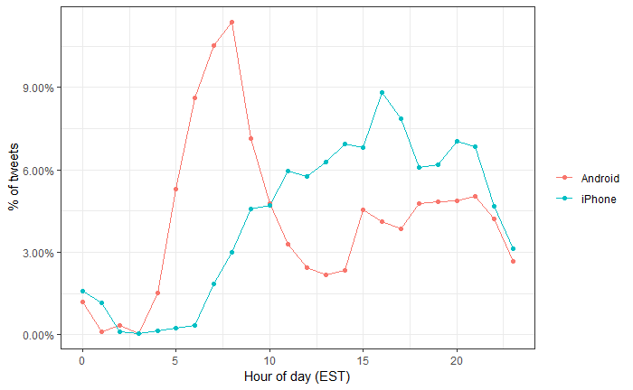

```r
ds_theme_set()
campaing_tweets %>%
  mutate(hour = hour(with_tz(created_at,"EST"))) %>%
  count(source, hour) %>%
  group_by(source) %>%
  mutate(percent = n/sum(n)) %>%
  ungroup %>%
  ggplot(aes(hour,percent, color=source)) +
  geom_line() +
  geom_point() +
  scale_y_continuous(labels=percent_format()) +
  labs(x = "Hour of day (EST)",
       y = "% of tweets",
       color = "")
```

We notice a big peak for the Android in early hours of the morning, between 6 and 8 AM. There seems to be a clear different in these patterns. We will therefore assume that two different entities are using these two devices. Now we will study how their tweets differ. To do this we introduce the tidytext package.

## Text as data

The tidytext package helps us convert free from text into a tidy table. Having the data in this format greatly facilitates data visualization and applying statistical techniques.

```r
library(tidytext)
```

The main function needed to achieve this is `unnest_tokens`. A *token* refers to the units that we are considering to be a data point. The most common token will be words, but they can also be single characters, ngrams, sentences, lines or a pattern defined by a regex. The functions will take a vector of strings and extract the tokens so that each one gets a row in the new table. Here is a simple example:

```r
example <- data_frame(line = c(1,2,3,4),
                      text= c("Roses are red,", "Violets are blue,", "Sugar is sweet,", "And so are you."))
example
```

```
# A tibble: 4 x 2
   line text
  <dbl> <chr>
1     1 Roses are red,
2     2 Violets are blue,
3     3 Sugar is sweet,
4     4 And so are you.
```

```r
example %>% unnest_tokens(word, text)
```

```
# A tibble: 13 x 2
    line word
   <dbl> <chr>
 1     1 roses
 2     1 are
 3     1 red
 4     2 violets
 5     2 are
 6     2 blue
 7     3 sugar
 8     3 is
 9     3 sweet
10     4 and
11     4 so
12     4 are
13     4 you
```

Now let’s look at a quick example with a tweet number 3008

```r
i <- 3008
campaing_tweets$text[i]
```

```
[1] "Great to be back in Iowa! #TBT with @JerryJrFalwell joining me in Davenport- this past winter. #MAGA https://t.co/A5IF0QHnic"
```

```r
campaing_tweets[i,] %>%
  unnest_tokens(word,text) %>%
  select(word)
```

```
                  word
3008             great
3008.1              to
3008.2              be
3008.3            back
3008.4              in
3008.5            iowa
3008.6             tbt
3008.7            with
3008.8  jerryjrfalwell
3008.9         joining
3008.10             me
3008.11             in
3008.12      davenport
3008.13           this
3008.14           past
3008.15         winter
3008.16           maga
3008.17          https
3008.18           t.co
3008.19     a5if0qhnic
```

Note that the function tries to convert tokens into words and strips characters important to twitter such as # and @. A token in twitter is not the same as in regular english. For this reason instead of using the default, words, we define a regex that captures twitter character. The pattern appears complex but all we are defining is a patter that starts with @, # or neither and is followed by any combination of letter or digits:

```r
pattern <- "([^A-Za-z\\d#@']|'(?![A-Za-z\\d#@]))"
```

We can now use the `unnest_tokens` function with the `regex` option and appropriately extract the hashtags and mentions:

```r
campaing_tweets[i,] %>%
  unnest_tokens(word, text, token= "regex", pattern = pattern) %>%
  select(word)
```

```
              word
1            great
2               to
3               be
4             back
5               in
6             iowa
7             #tbt
8             with
9  @jerryjrfalwell
10         joining
11              me
12              in
13       davenport
14            this
15            past
16          winter
17           #maga
18           https
19               t
20              co
21      a5if0qhnic
```

Another minor adjustment we want to make is remove the links to pictures:

```r
campaing_tweets[i,] %>%
  mutate(text = str_replace_all(text, "https://t.co/[A-Za-z\\d]+|&amp;","")) %>%
  unnest_tokens(word,text, token = "regex", pattern= pattern) %>%
  select(word)
```

```
              word
1            great
2               to
3               be
4             back
5               in
6             iowa
7             #tbt
8             with
9  @jerryjrfalwell
10         joining
11              me
12              in
13       davenport
14            this
15            past
16          winter
17           #maga
```

And we can now answer questions such as “what are the most commonly used words?”

```r
tweet_words %>%
  count(word) %>%
  arrange(desc(n))
```

```
# A tibble: 6,724 x 2
   word      n
   <chr> <int>
 1 the    2335
 2 to     1413
 3 and    1246
 4 a      1210
 5 in     1189
 6 i      1161
 7 you    1000
 8 of      983
 9 is      944
10 on      880
# ... with 6,714 more rows
```

It is not surprising that these are the top words. The top words are not informative. The *tidytext* package has database of these commonly used words, referred to as *stop words*, in text mining:

```r
stop_words
```

```
# A tibble: 1,149 x 2
   word        lexicon
   <chr>       <chr>
 1 a           SMART
 2 a's         SMART
 3 able        SMART
 4 about       SMART
 5 above       SMART
 6 according   SMART
 7 accordingly SMART
 8 across      SMART
 9 actually    SMART
10 after       SMART
# ... with 1,139 more rows
```

If we filter out rows representing stop words with `filter(!word %in% stop_words$word)`

```r
tweet_words <- campaign_tweet %>%
  mutate(text=str_replace_all(text,"https://t.co/[A-Za-z\\d]+|&amp;", "")) %>%
  unnest_tokens(word, text, token = "regex", pattern= pattern) %>%
  filter(!word %in% stop_words)
```

[output not shown]

```r
head(tweet_words)
```

```
   source             id_str          created_at retweet_count in_reply_to_user_id_str
1 Android 612063082186174464 2015-06-19 20:03:05           166                    <NA>
2 Android 612063082186174464 2015-06-19 20:03:05           166                    <NA>
3 Android 612063082186174464 2015-06-19 20:03:05           166                    <NA>
4 Android 612063082186174464 2015-06-19 20:03:05           166                    <NA>
5 Android 612063082186174464 2015-06-19 20:03:05           166                    <NA>
6 Android 612063082186174464 2015-06-19 20:03:05           166                    <NA>
  favorite_count is_retweet        word
1            348      FALSE @danaperino
2            348      FALSE         beg
3            348      FALSE       tweet
4            348      FALSE endorsement
5            348      FALSE        book
6            348      FALSE    launched
```

Now that we have all our words in a table, along with information about what device was used to compose the tweet they came from, we can start exploring which words are more common when comparing Android to iPhone.

For each word we want to know if it is more likely to come from an Android tweet or an iPhone tweet. We previously introduced the odds ratio a summary statistic useful for quantifying these differences. We each device and a given word, let’s call it `y`, we compute the odds or the ratio between the proportion of words that are `y` and not `y` and compute the ratio of those odds. Here we will have many proportions that are 0 so we use the 0.5 correction.

```r
android_iphone_or %>% arrange(or)
```

```
# A tibble: 5,509 x 4
   word                   Android iPhone      or
   <chr>                    <dbl>  <dbl>   <dbl>
 1 #makeamericagreatagain       0    296 0.00144
 2 #americafirst                0     71 0.00607
 3 #draintheswamp               0     63 0.00683
 4 #trump2016                   3    412 0.00718
 5 #votetrump                   0     56 0.00769
 6 join                         1    157 0.00821
 7 #imwithyou                   0     51 0.00843
 8 #crookedhillary              0     30 0.0143
 9 #fitn                        0     30 0.0143
10 #gopdebate                   0     30 0.0143
# ... with 5,499 more rows
```

We already see somewhat of a pattern in the types of words that are being tweeted more in one device versus the other. However, we are not interested in specific words but rather in the tone. Vaziri’s assertion is that the Android tweets are more hyperbolic. So how can we check this with data? Hyperbolic is a hard sentiment to extract from words as it relies on interpreting phrases. However, words can be associated to more basic sentiment such as as anger, fear, joy and surprise. In the next section we demonstrate basic sentiment analysis.

## Sentiment Analysis

In sentiment analysis we assign a word to one or more “sentiment”. Although this approach will miss context dependent sentiments, such as sarcasm, when performed on large numbers of words, summaries can provide insights.

The first step in sentiment analysis is to assign a sentiment to each word. The tidytext package includes several maps or lexicons in the object `sentiments`:

```r
table(sentiments$lexicon)
```

```
   AFINN     bing loughran      nrc
    2476     6788     4149    13901
```

The `bing` lexicon divides words into `positive` and `negative`. We can see this using the *tidytext* function `get_sentiments`:

```r
get_sentiments("bing")
```

```
# A tibble: 6,788 x 2
   word        sentiment
   <chr>       <chr>
 1 2-faced     negative
 2 2-faces     negative
 3 a+          positive
 4 abnormal    negative
 5 abolish     negative
 6 abominable  negative
 7 abominably  negative
 8 abominate   negative
 9 abomination negative
10 abort       negative
# ... with 6,778 more rows
```

The `AFINN` lexicon assigns a score between -5 and 5, with -5 the most negative and 5 the most positive.

```r
get_sentiments("afinn")
```

```
# A tibble: 2,476 x 2
   word       score
   <chr>      <int>
 1 abandon       -2
 2 abandoned     -2
 3 abandons      -2
 4 abducted      -2
 5 abduction     -2
 6 abductions    -2
 7 abhor         -3
 8 abhorred      -3
 9 abhorrent     -3
10 abhors        -3
# ... with 2,466 more rows
```

The `loughran` and `nrc` lexicons provide several different sentiments:

```r
get_sentiments("loughran") %>% count(sentiment)
```

```
# A tibble: 6 x 2
  sentiment        n
  <chr>        <int>
1 constraining   184
2 litigious      903
3 negative      2355
4 positive       354
5 superfluous     56
6 uncertainty    297
```

```r
get_sentiments("nrc") %>% count(sentiment)
```

```
# A tibble: 10 x 2
   sentiment        n
   <chr>        <int>
 1 anger         1247
 2 anticipation   839
 3 disgust       1058
 4 fear          1476
 5 joy            689
 6 negative      3324
 7 positive      2312
 8 sadness       1191
 9 surprise       534
10 trust         1231
```

To start learning about how these lexicons were developed read this help file `?sentiments`.

We can combine the words and sentiments using `inner_join`, which will only keep words associated with a sentiment. Here are 10 random words extracted from the tweets:

```r
tweet_words %>% inner_join(nrc, by = "word") %>%
  select(source, word, sentiment) %>% sample_n(10)
```

```
       source     word    sentiment
4545  Android    phony        anger
6369  Android     vote          joy
9804  Android   virtue        trust
15542  iPhone tomorrow anticipation
3451  Android  finally        trust
15372  iPhone    honor        trust
16163  iPhone     vote     negative
11305  iPhone     bomb      sadness
10763  iPhone negative      sadness
1057  Android   spirit     positive
```

Now we are ready to perform a quantitative analysis comparing Android and iPhone by comparing the sentiments of the tweets posted from each device. Here we could perform a tweet by tweet analysis, assigning a sentiment to each tweet. However, this somewhat complex since each tweet will have several sentiments attached to it, one for each word appearing in the lexicon. For illustrative purposes we will perform a much simpler analysis: we will count and compare the frequencies of each sentiment appears for each device.

```r
sentiment_counts
```

```
# A tibble: 11 x 3
   sentiment    Android iPhone
   <chr>          <int>  <int>
 1 anger            965    527
 2 anticipation     915    710
 3 disgust          641    318
 4 fear             802    486
 5 joy              698    540
 6 negative        1668    935
 7 positive        1834   1497
 8 sadness          907    514
 9 surprise         530    365
10 trust           1253   1010
11 none           11523  10739
```

Because more words were used on the Android than on the phone:

```r
tweet_words %>% group_by(source) %>% summarize(n=n())
```

```
# A tibble: 2 x 2
  source      n
  <chr>   <int>
1 Android 15829
2 iPhone  13802
```

For each sentiment we can compute the odds of being in the device: proportion of words with sentiment versus proportion of words without and then compute the odds ratio comparing the two devices

```r
sentiment_counts %>%
  mutate(Android = Android / (sum(Android) - Android),
         iPhone = iPhone / (sum(iPhone) - iPhone),
         or = Android/iPhone) %>%
arrange(desc(or))
```

```
# A tibble: 11 x 4
   sentiment    Android iPhone    or
   <chr>          <dbl>  <dbl> <dbl>
 1 disgust       0.0304 0.0184 1.66
 2 anger         0.0465 0.0308 1.51
 3 negative      0.0831 0.0560 1.49
 4 sadness       0.0435 0.0300 1.45
 5 fear          0.0383 0.0283 1.35
 6 surprise      0.0250 0.0211 1.18
 7 joy           0.0332 0.0316 1.05
 8 anticipation  0.0439 0.0419 1.05
 9 trust         0.0612 0.0607 1.01
10 positive      0.0922 0.0927 0.994
11 none          1.13   1.56   0.725
```

So we do see some difference and the order is interesting: the largest three sentiments are disgust, anger, and negative! But are they statistically significant? How does this compare if we are just assigning sentiments at random?

```r
log_or
```

```
# A tibble: 11 x 7
   sentiment    Android iPhone   log_or     se conf.low conf.high
   <chr>          <int>  <int>    <dbl>  <dbl>    <dbl>     <dbl>
 1 disgust          641    318  0.504   0.0694   0.368     0.640
 2 anger            965    527  0.411   0.0551   0.303     0.519
 3 negative        1668    935  0.395   0.0422   0.313     0.478
 4 sadness          907    514  0.372   0.0562   0.262     0.482
 5 fear             802    486  0.302   0.0584   0.187     0.416
 6 surprise         530    365  0.168   0.0688   0.0332    0.303
 7 joy              698    540  0.0495  0.0582  -0.0647    0.164
 8 anticipation     915    710  0.0468  0.0511  -0.0533    0.147
 9 trust           1253   1010  0.00726 0.0436  -0.0781    0.0926
10 positive        1834   1497 -0.00624 0.0364  -0.0776    0.0651
11 none           11523  10739 -0.321   0.0206  -0.362    -0.281
```

A graphical visualization shows some sentiments that are clearly overrepresented:

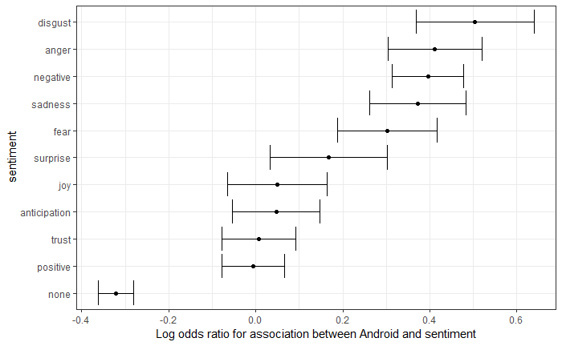

We see that the disgust, anger, negative sadness and fear sentiments are associated with the Android in a way that is hard to explain by chance alone. Words not associated to a sentiment were strongly associated with the iPhone source, whic is in agreement with the original claim about hyperbolic tweets.

If we are interested in exploring which specific words are driving these differences, we can back to our `android_iphone_or` object:

```r
android_iphone_or %>% inner_join(nrc) %>%
  filter(sentiment == "disgust" & Android + iPhone > 10) %>%
  arrange(desc(or))
```

```
# A tibble: 20 x 5
   word      Android iPhone    or sentiment
   <chr>       <dbl>  <dbl> <dbl> <chr>
 1 mess           15      2 5.41  disgust
 2 finally        12      2 4.36  disgust
 3 unfair         12      2 4.36  disgust
 4 bad           104     26 3.45  disgust
 5 lie            13      3 3.37  disgust
 6 terrible       31      8 3.24  disgust
 7 lying           9      3 2.37  disgust
 8 waste          12      5 1.98  disgust
 9 phony          21      9 1.97  disgust
10 illegal        32     14 1.96  disgust
11 nasty          14      6 1.95  disgust
12 pathetic       11      5 1.82  disgust
13 horrible       14      7 1.69  disgust
14 disaster       21     11 1.63  disgust
15 winning        14      9 1.33  disgust
16 liar            6      5 1.03  disgust
17 dishonest      37     32 1.01  disgust
18 john           24     21 0.994 disgust
19 dying           6      6 0.872 disgust
20 terrorism       9      9 0.872 disgust
```

We can make a graph

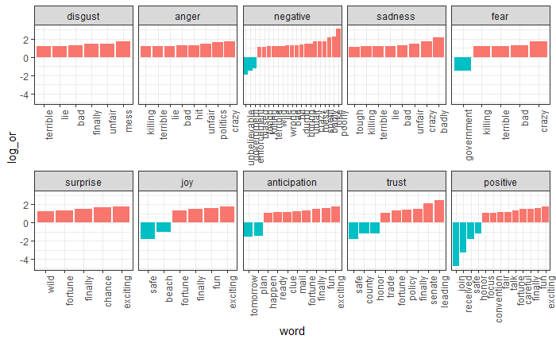